# Homework 4 Predictive analytics

Salma Elshahawy

2021-03-06

[Github repo](https://github.com/salma71/MSDS_spring2021/tree/master/data_624) | [portfolio](https://salma71.github.io/) | [Blog](https://salmaeng71.medium.com/)

## Problem_3.1

The UC Irvine Machine Learning Repository contains a data set related to glass identification. The data consists of 214 glass samples labeled as one of several class categories. There are nine predictors, including the refractive index and percentages of eight elements: Na, Mg, Al, Si, K, Ca, Ba, and Fe. The data can be accessed via:

```
#> 'data.frame':    214 obs. of  10 variables:
#>  $ RI  : num  1.52 1.52 1.52 1.52 1.52 ...
#>  $ Na  : num  13.6 13.9 13.5 13.2 13.3 ...
#>  $ Mg  : num  4.49 3.6 3.55 3.69 3.62 3.61 3.6 3.61 3.58 3.6 ...
#>  $ Al  : num  1.1 1.36 1.54 1.29 1.24 1.62 1.14 1.05 1.37 1.36 ...
#>  $ Si  : num  71.8 72.7 73 72.6 73.1 ...
#>  $ K   : num  0.06 0.48 0.39 0.57 0.55 0.64 0.58 0.57 0.56 0.57 ...
#>  $ Ca  : num  8.75 7.83 7.78 8.22 8.07 8.07 8.17 8.24 8.3 8.4 ...
#>  $ Ba  : num  0 0 0 0 0 0 0 0 0 0 ...
#>  $ Fe  : num  0 0 0 0 0 0.26 0 0 0 0.11 ...
#>  $ Type: Factor w/ 6 levels "1","2","3","5",..: 1 1 1 1 1 1 1 1 1 1 ...
```

**a. Using visualizations, explore the predictor variables to understand their distributions as well as the relationships between predictors**

I will start by conducting a uni-variate analysis for each predictor to study the distribution.

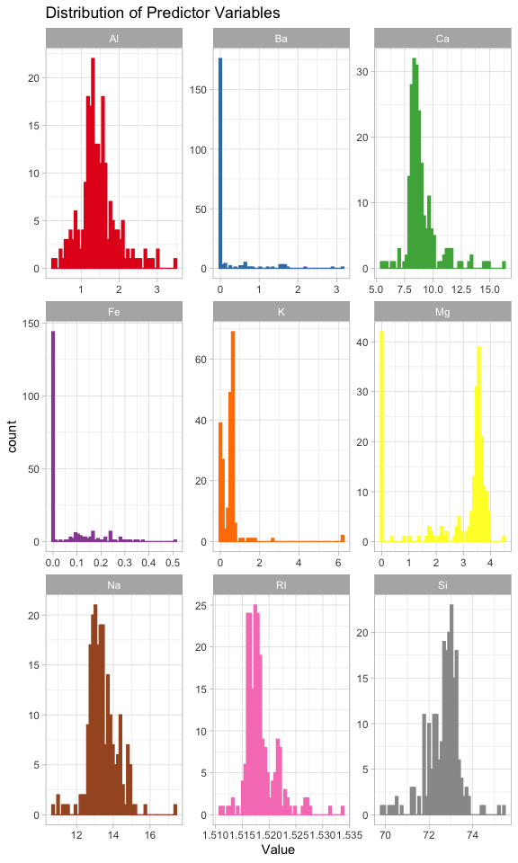

`RI`, `Si`, `Na`, `AI`, and `Ca` have Gausian normal distribution. However, the rest of the variables are either severly skewed with long tail to the right, or has a bi modal distribution such as the `Mg`. We can consider to normalize/standardize the data or make a transformation to make the predictors have more reliability in building the model.

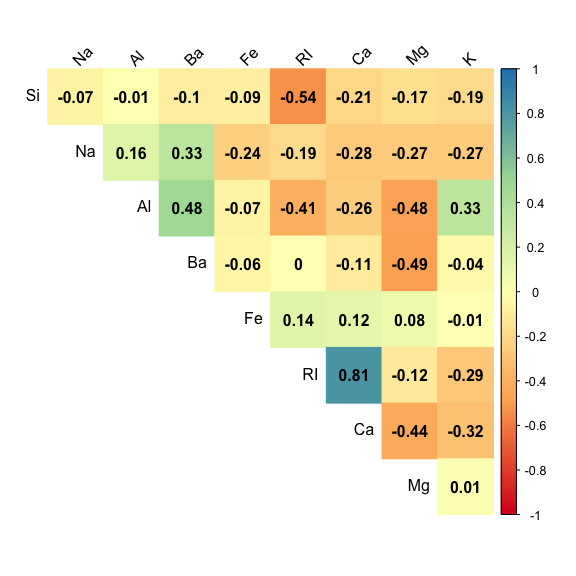

Most of the predictors are negatively correlated with each other.

**b. Do there appear to be any outliers in the data? Are any predictors skewed?**

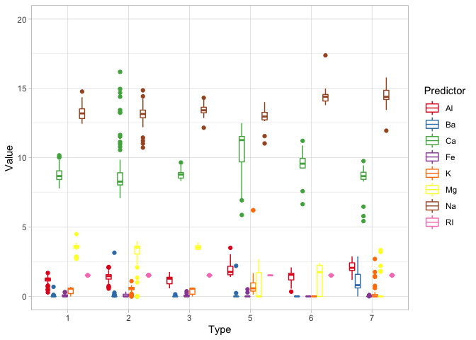

**c. Are there any relevant transformations of one or more predictors that might improve the classification model?**

yes, I would consider a transformation, Boxcox transformation or log-transformation.

## Problem_3.2

The soybean data can also be found at the UC Irvine Machine Learning Repository. Data were collected to predict disease in 683 soybeans. The 35 predictors are mostly categorical and include information on the environemental conditions (e.g. temperature, precipitation) and plant conditions (e.g., left spots, mold growth). The outcome labels consist of 19 distinct classes. The data can be loaded via:

```
#> 'data.frame':    683 obs. of  36 variables:
#>  $ Class          : Factor w/ 19 levels "2-4-d-injury",..: 11 11 11 11 11 11 11 11 11 11 ...
#>  $ date           : Factor w/ 7 levels "0","1","2","3",..: 7 5 4 4 7 6 6 5 7 5 ...
#>  $ plant.stand    : Ord.factor w/ 2 levels "0"<"1": 1 1 1 1 1 1 1 1 1 1 ...
#>  $ precip         : Ord.factor w/ 3 levels "0"<"1"<"2": 3 3 3 3 3 3 3 3 3 3 ...
#>  $ temp           : Ord.factor w/ 3 levels "0"<"1"<"2": 2 2 2 2 2 2 2 2 2 2 ...
#>  $ hail           : Factor w/ 2 levels "0","1": 1 1 1 1 1 1 1 2 1 1 ...
#>  $ crop.hist      : Factor w/ 4 levels "0","1","2","3": 2 3 2 2 3 4 3 2 4 3 ...
#>  $ area.dam       : Factor w/ 4 levels "0","1","2","3": 2 1 1 1 1 1 1 1 1 1 ...
#>  $ sever          : Factor w/ 3 levels "0","1","2": 2 3 3 3 2 2 2 2 2 3 ...
#>  $ seed.tmt       : Factor w/ 3 levels "0","1","2": 1 2 2 1 1 1 2 1 2 1 ...
#>  $ germ           : Ord.factor w/ 3 levels "0"<"1"<"2": 1 2 3 2 3 2 1 3 2 3 ...
#>  $ plant.growth   : Factor w/ 2 levels "0","1": 2 2 2 2 2 2 2 2 2 2 ...
#>  $ leaves         : Factor w/ 2 levels "0","1": 2 2 2 2 2 2 2 2 2 2 ...
#>  $ leaf.halo      : Factor w/ 3 levels "0","1","2": 1 1 1 1 1 1 1 1 1 1 ...
```

[output cut: 22 more lines]

**a. Investigate the frequency distributions for the categorical predictors. Are any of the distributions degenerate in the ways discussed earlier in this chapter?**

```
#>   date plant.stand precip temp hail crop.hist area.dam sever seed.tmt germ
#> 1    6           0      2    1    0         1        1     1        0    0
#> 2    4           0      2    1    0         2        0     2        1    1
#> 3    3           0      2    1    0         1        0     2        1    2
#> 4    3           0      2    1    0         1        0     2        0    1
#> 5    6           0      2    1    0         2        0     1        0    2
#> 6    5           0      2    1    0         3        0     1        0    1
#>   plant.growth leaves leaf.halo leaf.marg leaf.size leaf.shread leaf.malf
#> 1            1      1         0         2         2           0         0
#> 2            1      1         0         2         2           0         0
#> 3            1      1         0         2         2           0         0
#> 4            1      1         0         2         2           0         0
#> 5            1      1         0         2         2           0         0
#> 6            1      1         0         2         2           0         0
#>   leaf.mild stem lodging stem.cankers canker.lesion fruiting.bodies ext.decay
```

[output cut: 20 more lines]

**Roughly 18 % of the data are missing. Are there particular predictors that are more likely to be missing? Is the pattern of missing data related to the classes?**

I will start with counting the missing values in the Soybean.

```
#>            hail           sever        seed.tmt         lodging            germ
#>             121             121             121             121             112
#>       leaf.mild fruiting.bodies     fruit.spots   seed.discolor      shriveling
#>             108             106             106             106             106
#>     leaf.shread            seed     mold.growth       seed.size       leaf.halo
#>             100              92              92              92              84
#>       leaf.marg       leaf.size       leaf.malf      fruit.pods          precip
#>              84              84              84              84              38
#>    stem.cankers   canker.lesion       ext.decay        mycelium    int.discolor
#>              38              38              38              38              38
#>       sclerotia     plant.stand           roots            temp       crop.hist
#>              38              36              31              30              16
#>    plant.growth            stem            date        area.dam          leaves
#>              16              16               1               1               0
```

|  | 2-4-d-injury | alternarialeaf-spot | anthracnose | bacterial-blight | bacterial-pustule | brown-spot | brown-stem-rot | charcoal-rot | cyst-nematode | diaporthe-pod-&-stem-blight | diaporthe-stem-canker | downy-mildew | frog-eye-leaf-spot | herbicide-injury | phyllosticta-leaf-spot | phytophthora-rot | powdery-mildew | purple-seed-stain | rhizoctonia-root-rot |
| --- | --- | --- | --- | --- | --- | --- | --- | --- | --- | --- | --- | --- | --- | --- | --- | --- | --- | --- | --- |
| hail | 16 | 0 | 0 | 0 | 0 | 0 | 0 | 0 | 14 | 15 | 0 | 0 | 0 | 8 | 0 | 68 | 0 | 0 | 0 |
| sever | 16 | 0 | 0 | 0 | 0 | 0 | 0 | 0 | 14 | 15 | 0 | 0 | 0 | 8 | 0 | 68 | 0 | 0 | 0 |
| seed.tmt | 16 | 0 | 0 | 0 | 0 | 0 | 0 | 0 | 14 | 15 | 0 | 0 | 0 | 8 | 0 | 68 | 0 | 0 | 0 |
| lodging | 16 | 0 | 0 | 0 | 0 | 0 | 0 | 0 | 14 | 15 | 0 | 0 | 0 | 8 | 0 | 68 | 0 | 0 | 0 |
| germ | 16 | 0 | 0 | 0 | 0 | 0 | 0 | 0 | 14 | 6 | 0 | 0 | 0 | 8 | 0 | 68 | 0 | 0 | 0 |
| leaf.mild | 16 | 0 | 0 | 0 | 0 | 0 | 0 | 0 | 14 | 15 | 0 | 0 | 0 | 8 | 0 | 55 | 0 | 0 | 0 |
| fruiting.bodies | 16 | 0 | 0 | 0 | 0 | 0 | 0 | 0 | 14 | 0 | 0 | 0 | 0 | 8 | 0 | 68 | 0 | 0 | 0 |
| fruit.spots | 16 | 0 | 0 | 0 | 0 | 0 | 0 | 0 | 14 | 0 | 0 | 0 | 0 | 8 | 0 | 68 | 0 | 0 | 0 |
| seed.discolor | 16 | 0 | 0 | 0 | 0 | 0 | 0 | 0 | 14 | 0 | 0 | 0 | 0 | 8 | 0 | 68 | 0 | 0 | 0 |
| shriveling | 16 | 0 | 0 | 0 | 0 | 0 | 0 | 0 | 14 | 0 | 0 | 0 | 0 | 8 | 0 | 68 | 0 | 0 | 0 |
| leaf.shread | 16 | 0 | 0 | 0 | 0 | 0 | 0 | 0 | 14 | 15 | 0 | 0 | 0 | 0 | 0 | 55 | 0 | 0 | 0 |
| seed | 16 | 0 | 0 | 0 | 0 | 0 | 0 | 0 | 0 | 0 | 0 | 0 | 0 | 8 | 0 | 68 | 0 | 0 | 0 |
| mold.growth | 16 | 0 | 0 | 0 | 0 | 0 | 0 | 0 | 0 | 0 | 0 | 0 | 0 | 8 | 0 | 68 | 0 | 0 | 0 |
| seed.size | 16 | 0 | 0 | 0 | 0 | 0 | 0 | 0 | 0 | 0 | 0 | 0 | 0 | 8 | 0 | 68 | 0 | 0 | 0 |
| leaf.halo | 0 | 0 | 0 | 0 | 0 | 0 | 0 | 0 | 14 | 15 | 0 | 0 | 0 | 0 | 0 | 55 | 0 | 0 | 0 |
| leaf.marg | 0 | 0 | 0 | 0 | 0 | 0 | 0 | 0 | 14 | 15 | 0 | 0 | 0 | 0 | 0 | 55 | 0 | 0 | 0 |
| leaf.size | 0 | 0 | 0 | 0 | 0 | 0 | 0 | 0 | 14 | 15 | 0 | 0 | 0 | 0 | 0 | 55 | 0 | 0 | 0 |
| leaf.malf | 0 | 0 | 0 | 0 | 0 | 0 | 0 | 0 | 14 | 15 | 0 | 0 | 0 | 0 | 0 | 55 | 0 | 0 | 0 |
| fruit.pods | 16 | 0 | 0 | 0 | 0 | 0 | 0 | 0 | 0 | 0 | 0 | 0 | 0 | 0 | 0 | 68 | 0 | 0 | 0 |
| precip | 16 | 0 | 0 | 0 | 0 | 0 | 0 | 0 | 14 | 0 | 0 | 0 | 0 | 8 | 0 | 0 | 0 | 0 | 0 |
| stem.cankers | 16 | 0 | 0 | 0 | 0 | 0 | 0 | 0 | 14 | 0 | 0 | 0 | 0 | 8 | 0 | 0 | 0 | 0 | 0 |
| canker.lesion | 16 | 0 | 0 | 0 | 0 | 0 | 0 | 0 | 14 | 0 | 0 | 0 | 0 | 8 | 0 | 0 | 0 | 0 | 0 |
| ext.decay | 16 | 0 | 0 | 0 | 0 | 0 | 0 | 0 | 14 | 0 | 0 | 0 | 0 | 8 | 0 | 0 | 0 | 0 | 0 |
| mycelium | 16 | 0 | 0 | 0 | 0 | 0 | 0 | 0 | 14 | 0 | 0 | 0 | 0 | 8 | 0 | 0 | 0 | 0 | 0 |
| int.discolor | 16 | 0 | 0 | 0 | 0 | 0 | 0 | 0 | 14 | 0 | 0 | 0 | 0 | 8 | 0 | 0 | 0 | 0 | 0 |
| sclerotia | 16 | 0 | 0 | 0 | 0 | 0 | 0 | 0 | 14 | 0 | 0 | 0 | 0 | 8 | 0 | 0 | 0 | 0 | 0 |
| plant.stand | 16 | 0 | 0 | 0 | 0 | 0 | 0 | 0 | 14 | 6 | 0 | 0 | 0 | 0 | 0 | 0 | 0 | 0 | 0 |
| roots | 16 | 0 | 0 | 0 | 0 | 0 | 0 | 0 | 0 | 15 | 0 | 0 | 0 | 0 | 0 | 0 | 0 | 0 | 0 |
| temp | 16 | 0 | 0 | 0 | 0 | 0 | 0 | 0 | 14 | 0 | 0 | 0 | 0 | 0 | 0 | 0 | 0 | 0 | 0 |
| crop.hist | 16 | 0 | 0 | 0 | 0 | 0 | 0 | 0 | 0 | 0 | 0 | 0 | 0 | 0 | 0 | 0 | 0 | 0 | 0 |
| plant.growth | 16 | 0 | 0 | 0 | 0 | 0 | 0 | 0 | 0 | 0 | 0 | 0 | 0 | 0 | 0 | 0 | 0 | 0 | 0 |
| stem | 16 | 0 | 0 | 0 | 0 | 0 | 0 | 0 | 0 | 0 | 0 | 0 | 0 | 0 | 0 | 0 | 0 | 0 | 0 |
| date | 1 | 0 | 0 | 0 | 0 | 0 | 0 | 0 | 0 | 0 | 0 | 0 | 0 | 0 | 0 | 0 | 0 | 0 | 0 |
| area.dam | 1 | 0 | 0 | 0 | 0 | 0 | 0 | 0 | 0 | 0 | 0 | 0 | 0 | 0 | 0 | 0 | 0 | 0 | 0 |
| leaves | 0 | 0 | 0 | 0 | 0 | 0 | 0 | 0 | 0 | 0 | 0 | 0 | 0 | 0 | 0 | 0 | 0 | 0 | 0 |

The numbers are the count of missing values for the predictors.

From this table, it seems that some predictors have same rows with missing values, and the same distribution of classes. Furthere, these predictors’ missing values are biased toward the class phytophthorarot. For example, for the predictor hail, out of the 121 missing values, 68 (56%) of them are phytophthorarot. This indicates “informative missingness”, which can induce significant bias in the model.

**c. Develop a strategy for handling missing data, either by eliminating predictors or imputation.**

```
#> [1] "Eliminated 68 rows."
```

```
#> [1] "615 rows remaining."
```

```
#> [1] "53 rows still contain missing values."
```

```
#> [1] "Filling 1 missing values for feature:  date ."
#> [1] "The most frequent factor of this feature is: 5 , which is 24.27 % of the class."
#> [1] "------------------------------------------------"
#> [1] "Filling 36 missing values for feature:  plant.stand ."
#> [1] "The most frequent factor of this feature is: 0 , which is 61.14 % of the class."
#> [1] "------------------------------------------------"
#> [1] "Filling 38 missing values for feature:  precip ."
#> [1] "The most frequent factor of this feature is: 2 , which is 72.27 % of the class."
#> [1] "------------------------------------------------"
#> [1] "Filling 30 missing values for feature:  temp ."
#> [1] "The most frequent factor of this feature is: 1 , which is 57.09 % of the class."
#> [1] "------------------------------------------------"
#> [1] "Filling 53 missing values for feature:  hail ."
#> [1] "The most frequent factor of this feature is: 0 , which is 77.4 % of the class."
#> [1] "------------------------------------------------"
```

[output cut: 90 more lines]

```
#> [1] "There are now 615 rows. 0 rows have missing values."
```

[Github repo](https://github.com/salma71/MSDS_spring2021/tree/master/data_624) | [portfolio](https://salma71.github.io/) | [Blog](https://salmaeng71.medium.com/)